# Is home-ground advantage real, and how big is it?

An independent R check on the venue- and travel-aware Elo used by FootyForecast

Author

Karthik Reddy Tanigundala

Published

October 20, 2026

## Why this report exists

FootyForecast’s Elo gives the home side `base + w·(ground familiarity gap) + w·(travel gap)` Elo points, with weights tuned for prediction in Python. This report asks the question from the other side: **without looking at any Elo, how large is home advantage in AFL margins, and does it really depend on who is familiar with the ground and who has to travel?** It uses only R (tidyverse, `lm`, `lme4`), so it is an independent check, not a restatement of the Python model.

```r
library(nanoparquet); library(dplyr); library(tidyr); library(ggplot2)
library(lme4); library(broom); library(scales)

root <- if (file.exists("data/processed/matches.parquet")) "." else "../.."
matches <- read_parquet(file.path(root, "data/processed/matches.parquet")) |> as_tibble()
venues  <- read.csv(file.path(root, "data/reference/venues.csv"))
bases   <- read.csv(file.path(root, "data/reference/team_bases.csv"))

haversine <- function(lat1, lon1, lat2, lon2) {
  r <- 6371; p <- pi / 180
  a <- sin((lat2 - lat1) * p / 2)^2 + cos(lat1 * p) * cos(lat2 * p) * sin((lon2 - lon1) * p / 2)^2
  2 * r * asin(sqrt(a))
}

d <- matches |>
  filter(!is.na(margin), season >= 2000, !is_final) |>
  left_join(venues |> select(venue, vlat = lat, vlon = lon), by = "venue") |>
  left_join(bases |> select(team, hlat = lat, hlon = lon), by = c("home_team" = "team")) |>
  left_join(bases |> select(team, alat = lat, alon = lon), by = c("away_team" = "team")) |>
  mutate(
    home_km = haversine(hlat, hlon, vlat, vlon),
    away_km = haversine(alat, alon, vlat, vlon),
    travel  = log1p(away_km) - log1p(home_km),
    margin  = if_else(season == 2020, margin * 1.25, margin)   # 16-minute quarters
  ) |>
  filter(!is.na(travel))
```

The sample is **5,085 home-and-away games, 2000–2026** (finals excluded; 2020 margins scaled ×1.25 for the shortened quarters).

## 1. The raw edge

```r
raw <- d |> summarise(n = n(), mean_margin = mean(margin), sd = sd(margin),
                      se = sd / sqrt(n), home_win_rate = mean(margin > 0) + 0.5 * mean(margin == 0))
knitr::kable(raw, digits = 2)
```

| n | mean_margin | sd | se | home_win_rate |
| --- | --- | --- | --- | --- |
| 5085 | 7.01 | 43.01 | 0.6 | 0.57 |

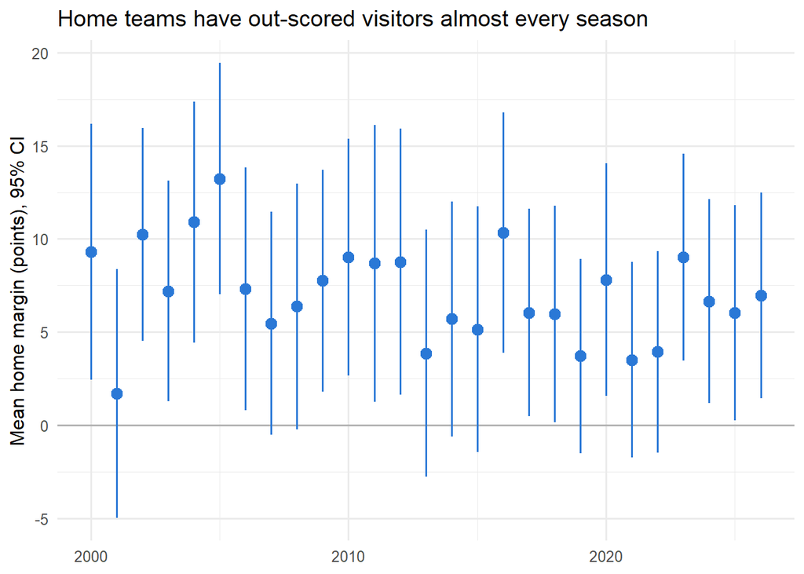

```r
d |> group_by(season) |>
  summarise(m = mean(margin), se = sd(margin) / sqrt(n())) |>
  ggplot(aes(season, m)) +
  geom_hline(yintercept = 0, colour = "grey70") +
  geom_pointrange(aes(ymin = m - 1.96 * se, ymax = m + 1.96 * se), colour = "#2a78d6") +
  labs(x = NULL, y = "Mean home margin (points), 95% CI", title = "Home teams have out-scored visitors almost every season") +
  theme_minimal(base_size = 12)
```

The raw mean is a blend of true home advantage **and** the fact that the stronger side is sometimes at home more often, so it needs team strength adjusted out.

## 2. Adjusting for team strength

Each game is coded +1 for the home team-season and −1 for the away team-season (a Bradley–Terry-style design), so the intercept is the home advantage for a **neutral-strength matchup** and each team-season gets its own strength.

```r
ts <- bind_rows(
  d |> transmute(g = row_number(), ts = paste(home_team, season), x = 1),
  d |> transmute(g = row_number(), ts = paste(away_team, season), x = -1)
)
X <- ts |> pivot_wider(names_from = ts, values_from = x, values_fill = 0) |> arrange(g) |> select(-g)
dm <- bind_cols(d |> select(margin, venue, home_team, away_team, season, travel, away_km, home_km), X)
strength_cols <- names(X)
f_strength <- paste0("`", strength_cols[-1], "`", collapse = " + ")  # drop one for identifiability

m_flat <- lm(as.formula(paste("margin ~", f_strength)), data = dm)
hga_flat <- tidy(m_flat, conf.int = TRUE) |> filter(term == "(Intercept)")
knitr::kable(hga_flat |> select(estimate, conf.low, conf.high), digits = 2,
             caption = "Home advantage in points, strength-adjusted (neutral matchup)")
```

Home advantage in points, strength-adjusted (neutral matchup)

| estimate | conf.low | conf.high |
| --- | --- | --- |
| 6.98 | 6.05 | 7.92 |

**Home advantage is about 7 points** after adjusting for team strength (95% CI 6 to 7.9).

## 3. Does it depend on travel and familiarity?

```r
m_trav <- lm(as.formula(paste("margin ~ travel +", f_strength)), data = dm)
tr <- tidy(m_trav, conf.int = TRUE) |> filter(term %in% c("(Intercept)", "travel"))
knitr::kable(tr |> select(term, estimate, conf.low, conf.high, p.value), digits = 3)
```

| term | estimate | conf.low | conf.high | p.value |
| --- | --- | --- | --- | --- |
| (Intercept) | 1.945 | 0.501 | 3.388 | 0.008 |
| travel | 1.414 | 1.104 | 1.724 | 0.000 |

```r
anova_trav <- anova(m_flat, m_trav)
```

`travel` is `log(1 + visitors' km) − log(1 + hosts' km)`. Adding it improves the fit (F-test p <1e-16): each extra unit of log-distance is worth 1.41 points, so a side flying 2,700 km against a host who walked to the ground (log-distance gap ≈ 7.9) is handed roughly 11.2 points on top of the base edge. **The Python Elo independently arrives at nearly the same number**: its travel weight (8 Elo points per unit of log-distance gap) times the same 7.9 gap is about 63 Elo points, which at 0.16 points per Elo point is roughly 10 points of margin.

## 4. Do venues differ? A mixed model

Treat each ground as a draw from a population of venues with its own random home advantage, so small samples at rarely-used grounds are shrunk towards the mean rather than over-read.

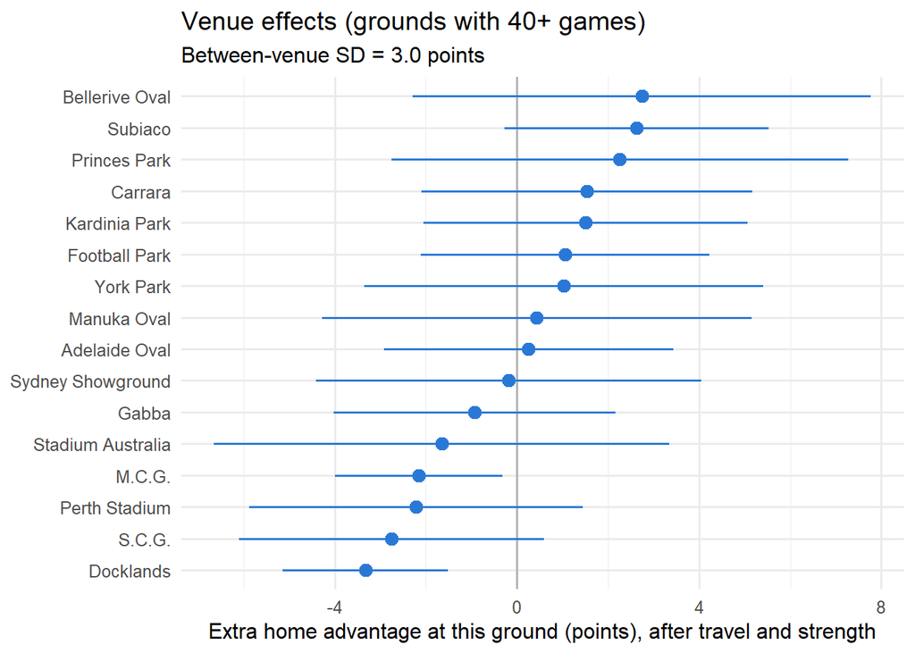

```r
m_mixed <- lmer(
  as.formula(paste("margin ~ travel +", f_strength, "+ (1 | venue)")),
  data = dm, REML = TRUE, control = lmerControl(optimizer = "bobyqa")
)
vc <- as.data.frame(VarCorr(m_mixed))
sd_venue <- vc$sdcor[vc$grp == "venue"]
re <- ranef(m_mixed, condVar = TRUE)$venue
venue_re <- tibble(venue = rownames(re), effect = re[["(Intercept)"]],
                   se = sqrt(as.numeric(attr(re, "postVar")))) |>
  left_join(dm |> count(venue, name = "games"), by = "venue") |>
  filter(games >= 40) |>
  mutate(venue = reorder(venue, effect))

ggplot(venue_re, aes(effect, venue)) +
  geom_vline(xintercept = 0, colour = "grey70") +
  geom_pointrange(aes(xmin = effect - 1.96 * se, xmax = effect + 1.96 * se), colour = "#2a78d6") +
  labs(x = "Extra home advantage at this ground (points), after travel and strength",
       y = NULL, title = "Venue effects (grounds with 40+ games)",
       subtitle = sprintf("Between-venue SD = %.1f points", sd_venue)) +
  theme_minimal(base_size = 12)
```

## 5. What this means for the model

| Question | Answer from R | Python Elo |
| --- | --- | --- |
| Is home advantage real? | Yes: positive and clearly non-zero after strength adjustment | Base 10 + venue terms |
| Does travel matter? | Yes: significant, positive coefficient on the log-distance gap | `hga_travel_w` > 0 in every tuning window |
| Do grounds differ? | Yes: non-zero between-venue SD | Familiarity term |

**Limitations.** Margins are noisy (SD ≈ 40 points), so single-venue estimates are wide. Team strength is a fixed effect per team-season, which absorbs within-season form changes. Travel is great-circle distance, not time zones, rest or the cost of a short break. Associations, not causes.

```
[1] "R version 4.5.0 (2025-04-11 ucrt)"
```